# Risk Factor Analysis

## Outcome Variable

**Outcome Variable:** ever_stunted

## Predictor Variables

**Intervention Variable:** tr

**Adjustment Set:**

unadjusted

## Stratifying Variables

The analysis was stratified on these variable(s):

- agecat
- studyid
- country
- intXpredexfd6

## Data Summary

| agecat | studyid | country | intXpredexfd6 | ever_stunted | n_cell | n |
| --- | --- | --- | --- | --- | --- | --- |
| 0-6 months | iLiNS_DYADM_LNS | MALAWI | 0_0-6 months | 0 | 0 | 1 |
| 0-6 months | iLiNS_DYADM_LNS | MALAWI | 0_0-6 months | 1 | 1 | 1 |
| 0-6 months | iLiNS_DYADM_LNS | MALAWI | 1_0-6 months | 0 | 1 | 1 |
| 0-6 months | iLiNS_DYADM_LNS | MALAWI | 1_0-6 months | 1 | 0 | 1 |
| 0-6 months | ki1000304b-SAS-CompFeed | INDIA | 0_0-6 months | 0 | 9 | 12 |
| 0-6 months | ki1000304b-SAS-CompFeed | INDIA | 0_0-6 months | 1 | 3 | 12 |
| 0-6 months | ki1000304b-SAS-CompFeed | INDIA | 1_0-6 months | 0 | 140 | 206 |
| 0-6 months | ki1000304b-SAS-CompFeed | INDIA | 1_0-6 months | 1 | 66 | 206 |
| 0-6 months | ki1000304b-SAS-FoodSuppl | INDIA | 0_0-6 months | 0 | 95 | 183 |
| 0-6 months | ki1000304b-SAS-FoodSuppl | INDIA | 0_0-6 months | 1 | 88 | 183 |
| 0-6 months | ki1017093b-PROVIDE | BANGLADESH | 0_0-6 months | 0 | 404 | 473 |
| 0-6 months | ki1017093b-PROVIDE | BANGLADESH | 0_0-6 months | 1 | 69 | 473 |
| 0-6 months | ki1017093b-PROVIDE | BANGLADESH | 1_0-6 months | 0 | 147 | 167 |
| 0-6 months | ki1017093b-PROVIDE | BANGLADESH | 1_0-6 months | 1 | 20 | 167 |
| 0-6 months | ki1148112-iLiNS-DOSE | MALAWI | 0_0-6 months | 0 | 110 | 161 |
| 0-6 months | ki1148112-iLiNS-DOSE | MALAWI | 0_0-6 months | 1 | 51 | 161 |
| 0-6 months | ki1148112-iLiNS-DOSE | MALAWI | 1_0-6 months | 0 | 727 | 1014 |
| 0-6 months | ki1148112-iLiNS-DOSE | MALAWI | 1_0-6 months | 1 | 287 | 1014 |
| 0-6 months | ki1148112-iLiNS-DYAD-M | MALAWI | 0_0-6 months | 0 | 0 | 2 |
| 0-6 months | ki1148112-iLiNS-DYAD-M | MALAWI | 0_0-6 months | 1 | 2 | 2 |
| 0-6 months | ki1148112-iLiNS-DYAD-M | MALAWI | 1_0-6 months | 0 | 2 | 2 |
| 0-6 months | ki1148112-iLiNS-DYAD-M | MALAWI | 1_0-6 months | 1 | 0 | 2 |
| 0-6 months | ki1148112-LCNI-5 | MALAWI | 0_0-6 months | 0 | 145 | 225 |
| 0-6 months | ki1148112-LCNI-5 | MALAWI | 0_0-6 months | 1 | 80 | 225 |
| 0-6 months | ki1148112-LCNI-5 | MALAWI | 1_0-6 months | 0 | 30 | 47 |
| 0-6 months | ki1148112-LCNI-5 | MALAWI | 1_0-6 months | 1 | 17 | 47 |
| 0-6 months | kiGH5241-JiVitA-3 | BANGLADESH | 0_0-6 months | 0 | 5604 | 8542 |
| 0-6 months | kiGH5241-JiVitA-3 | BANGLADESH | 0_0-6 months | 1 | 2938 | 8542 |
| 0-6 months | kiGH5241-JiVitA-3 | BANGLADESH | 1_0-6 months | 0 | 23202 | 30164 |
| 0-6 months | kiGH5241-JiVitA-3 | BANGLADESH | 1_0-6 months | 1 | 6962 | 30164 |
| 0-6 months | kiGH5241-JiVitA-4 | BANGLADESH | 0_0-6 months | 0 | 1374 | 1994 |
| 0-6 months | kiGH5241-JiVitA-4 | BANGLADESH | 0_0-6 months | 1 | 620 | 1994 |
| 0-6 months | kiGH5241-JiVitA-4 | BANGLADESH | 1_0-6 months | 0 | 5438 | 7110 |
| 0-6 months | kiGH5241-JiVitA-4 | BANGLADESH | 1_0-6 months | 1 | 1672 | 7110 |
| 6-24 months | iLiNS_DYADM_LNS | MALAWI | 0_6-24 months | 0 | 2 | 3 |
| 6-24 months | iLiNS_DYADM_LNS | MALAWI | 0_6-24 months | 1 | 1 | 3 |
| 6-24 months | iLiNS_DYADM_LNS | MALAWI | 1_6-24 months | 0 | 30 | 35 |
| 6-24 months | iLiNS_DYADM_LNS | MALAWI | 1_6-24 months | 1 | 5 | 35 |
| 6-24 months | ki1000304b-SAS-CompFeed | INDIA | 0_6-24 months | 0 | 7 | 10 |
| 6-24 months | ki1000304b-SAS-CompFeed | INDIA | 0_6-24 months | 1 | 3 | 10 |
| 6-24 months | ki1000304b-SAS-CompFeed | INDIA | 1_6-24 months | 0 | 104 | 189 |
| 6-24 months | ki1000304b-SAS-CompFeed | INDIA | 1_6-24 months | 1 | 85 | 189 |
| 6-24 months | ki1000304b-SAS-FoodSuppl | INDIA | 0_6-24 months | 0 | 34 | 91 |
| 6-24 months | ki1000304b-SAS-FoodSuppl | INDIA | 0_6-24 months | 1 | 57 | 91 |
| 6-24 months | ki1017093b-PROVIDE | BANGLADESH | 0_6-24 months | 0 | 227 | 260 |
| 6-24 months | ki1017093b-PROVIDE | BANGLADESH | 0_6-24 months | 1 | 33 | 260 |
| 6-24 months | ki1017093b-PROVIDE | BANGLADESH | 1_6-24 months | 0 | 78 | 82 |
| 6-24 months | ki1017093b-PROVIDE | BANGLADESH | 1_6-24 months | 1 | 4 | 82 |
| 6-24 months | ki1148112-iLiNS-DOSE | MALAWI | 0_6-24 months | 0 | 67 | 97 |
| 6-24 months | ki1148112-iLiNS-DOSE | MALAWI | 0_6-24 months | 1 | 30 | 97 |
| 6-24 months | ki1148112-iLiNS-DOSE | MALAWI | 1_6-24 months | 0 | 416 | 633 |
| 6-24 months | ki1148112-iLiNS-DOSE | MALAWI | 1_6-24 months | 1 | 217 | 633 |
| 6-24 months | ki1148112-iLiNS-DYAD-M | MALAWI | 0_6-24 months | 0 | 2 | 3 |
| 6-24 months | ki1148112-iLiNS-DYAD-M | MALAWI | 0_6-24 months | 1 | 1 | 3 |
| 6-24 months | ki1148112-iLiNS-DYAD-M | MALAWI | 1_6-24 months | 0 | 44 | 55 |
| 6-24 months | ki1148112-iLiNS-DYAD-M | MALAWI | 1_6-24 months | 1 | 11 | 55 |
| 6-24 months | ki1148112-LCNI-5 | MALAWI | 0_6-24 months | 0 | 80 | 134 |
| 6-24 months | ki1148112-LCNI-5 | MALAWI | 0_6-24 months | 1 | 54 | 134 |
| 6-24 months | ki1148112-LCNI-5 | MALAWI | 1_6-24 months | 0 | 17 | 28 |
| 6-24 months | ki1148112-LCNI-5 | MALAWI | 1_6-24 months | 1 | 11 | 28 |
| 6-24 months | kiGH5241-JiVitA-3 | BANGLADESH | 0_6-24 months | 0 | 2600 | 3214 |
| 6-24 months | kiGH5241-JiVitA-3 | BANGLADESH | 0_6-24 months | 1 | 614 | 3214 |
| 6-24 months | kiGH5241-JiVitA-3 | BANGLADESH | 1_6-24 months | 0 | 12004 | 14420 |
| 6-24 months | kiGH5241-JiVitA-3 | BANGLADESH | 1_6-24 months | 1 | 2416 | 14420 |
| 6-24 months | kiGH5241-JiVitA-4 | BANGLADESH | 0_6-24 months | 0 | 786 | 1130 |
| 6-24 months | kiGH5241-JiVitA-4 | BANGLADESH | 0_6-24 months | 1 | 344 | 1130 |
| 6-24 months | kiGH5241-JiVitA-4 | BANGLADESH | 1_6-24 months | 0 | 3344 | 4514 |
| 6-24 months | kiGH5241-JiVitA-4 | BANGLADESH | 1_6-24 months | 1 | 1170 | 4514 |

The following strata were considered:

- agecat: 0-6 months, studyid: iLiNS_DYADM_LNS, country: MALAWI, intXpredexfd6: 0_0-6 months
- agecat: 0-6 months, studyid: iLiNS_DYADM_LNS, country: MALAWI, intXpredexfd6: 1_0-6 months
- agecat: 0-6 months, studyid: ki1000304b-SAS-CompFeed, country: INDIA, intXpredexfd6: 0_0-6 months
- agecat: 0-6 months, studyid: ki1000304b-SAS-CompFeed, country: INDIA, intXpredexfd6: 1_0-6 months
- agecat: 0-6 months, studyid: ki1000304b-SAS-FoodSuppl, country: INDIA, intXpredexfd6: 0_0-6 months
- agecat: 0-6 months, studyid: ki1017093b-PROVIDE, country: BANGLADESH, intXpredexfd6: 0_0-6 months
- agecat: 0-6 months, studyid: ki1017093b-PROVIDE, country: BANGLADESH, intXpredexfd6: 1_0-6 months
- agecat: 0-6 months, studyid: ki1148112-iLiNS-DOSE, country: MALAWI, intXpredexfd6: 0_0-6 months
- agecat: 0-6 months, studyid: ki1148112-iLiNS-DOSE, country: MALAWI, intXpredexfd6: 1_0-6 months
- agecat: 0-6 months, studyid: ki1148112-iLiNS-DYAD-M, country: MALAWI, intXpredexfd6: 0_0-6 months
- agecat: 0-6 months, studyid: ki1148112-iLiNS-DYAD-M, country: MALAWI, intXpredexfd6: 1_0-6 months
- agecat: 0-6 months, studyid: ki1148112-LCNI-5, country: MALAWI, intXpredexfd6: 0_0-6 months
- agecat: 0-6 months, studyid: ki1148112-LCNI-5, country: MALAWI, intXpredexfd6: 1_0-6 months
- agecat: 0-6 months, studyid: kiGH5241-JiVitA-3, country: BANGLADESH, intXpredexfd6: 0_0-6 months
- agecat: 0-6 months, studyid: kiGH5241-JiVitA-3, country: BANGLADESH, intXpredexfd6: 1_0-6 months
- agecat: 0-6 months, studyid: kiGH5241-JiVitA-4, country: BANGLADESH, intXpredexfd6: 0_0-6 months
- agecat: 0-6 months, studyid: kiGH5241-JiVitA-4, country: BANGLADESH, intXpredexfd6: 1_0-6 months
- agecat: 6-24 months, studyid: iLiNS_DYADM_LNS, country: MALAWI, intXpredexfd6: 0_6-24 months
- agecat: 6-24 months, studyid: iLiNS_DYADM_LNS, country: MALAWI, intXpredexfd6: 1_6-24 months
- agecat: 6-24 months, studyid: ki1000304b-SAS-CompFeed, country: INDIA, intXpredexfd6: 0_6-24 months
- agecat: 6-24 months, studyid: ki1000304b-SAS-CompFeed, country: INDIA, intXpredexfd6: 1_6-24 months
- agecat: 6-24 months, studyid: ki1000304b-SAS-FoodSuppl, country: INDIA, intXpredexfd6: 0_6-24 months
- agecat: 6-24 months, studyid: ki1017093b-PROVIDE, country: BANGLADESH, intXpredexfd6: 0_6-24 months
- agecat: 6-24 months, studyid: ki1017093b-PROVIDE, country: BANGLADESH, intXpredexfd6: 1_6-24 months
- agecat: 6-24 months, studyid: ki1148112-iLiNS-DOSE, country: MALAWI, intXpredexfd6: 0_6-24 months
- agecat: 6-24 months, studyid: ki1148112-iLiNS-DOSE, country: MALAWI, intXpredexfd6: 1_6-24 months
- agecat: 6-24 months, studyid: ki1148112-iLiNS-DYAD-M, country: MALAWI, intXpredexfd6: 0_6-24 months
- agecat: 6-24 months, studyid: ki1148112-iLiNS-DYAD-M, country: MALAWI, intXpredexfd6: 1_6-24 months
- agecat: 6-24 months, studyid: ki1148112-LCNI-5, country: MALAWI, intXpredexfd6: 0_6-24 months
- agecat: 6-24 months, studyid: ki1148112-LCNI-5, country: MALAWI, intXpredexfd6: 1_6-24 months
- agecat: 6-24 months, studyid: kiGH5241-JiVitA-3, country: BANGLADESH, intXpredexfd6: 0_6-24 months
- agecat: 6-24 months, studyid: kiGH5241-JiVitA-3, country: BANGLADESH, intXpredexfd6: 1_6-24 months
- agecat: 6-24 months, studyid: kiGH5241-JiVitA-4, country: BANGLADESH, intXpredexfd6: 0_6-24 months
- agecat: 6-24 months, studyid: kiGH5241-JiVitA-4, country: BANGLADESH, intXpredexfd6: 1_6-24 months

### Dropped Strata

Some strata were dropped due to rare outcomes:

- agecat: 0-6 months, studyid: iLiNS_DYADM_LNS, country: MALAWI, intXpredexfd6: 0_0-6 months
- agecat: 0-6 months, studyid: iLiNS_DYADM_LNS, country: MALAWI, intXpredexfd6: 1_0-6 months
- agecat: 0-6 months, studyid: ki1000304b-SAS-CompFeed, country: INDIA, intXpredexfd6: 0_0-6 months
- agecat: 0-6 months, studyid: ki1148112-iLiNS-DYAD-M, country: MALAWI, intXpredexfd6: 0_0-6 months
- agecat: 0-6 months, studyid: ki1148112-iLiNS-DYAD-M, country: MALAWI, intXpredexfd6: 1_0-6 months
- agecat: 6-24 months, studyid: iLiNS_DYADM_LNS, country: MALAWI, intXpredexfd6: 0_6-24 months
- agecat: 6-24 months, studyid: ki1000304b-SAS-CompFeed, country: INDIA, intXpredexfd6: 0_6-24 months
- agecat: 6-24 months, studyid: ki1017093b-PROVIDE, country: BANGLADESH, intXpredexfd6: 1_6-24 months
- agecat: 6-24 months, studyid: ki1148112-iLiNS-DYAD-M, country: MALAWI, intXpredexfd6: 0_6-24 months

## Methods Detail

We’re interested in the causal parameters $E[Y_a]$ for all values of $a \in \mathcal{A}$. These parameters represent the mean outcome if, possibly contrary to fact, we intervened to set all units to have $A=a$. Under the randomization and positivity assumptions, these are identified by the statistical parameters $\psi_a=E_W[E_{Y|A,W}(Y|A=a,W)]$. In addition, we’re interested in the mean of $Y$, $E[Y]$ under no intervention (the observed mean). We will estimate these parameters by using SuperLearner to fit the relevant likelihood factors – $E_{Y|A,W}(Y|A=a,W)$ and $p(A=a|W)$, and then updating our likelihood fit using a joint TMLE.

For unadjusted analyses ($W=\{\}$), initial likelihoods were estimated using Lrnr_glm to estimate the simple $E(Y|A)$ and Lrnr_mean to estimate $p(A)$. For adjusted analyses, a small library containing Lrnr_glmnet, Lrnr_xgboost, and Lrnr_mean was used.

Having estimated these parameters, we will then use the delta method to estimate relative risks and attributable risks relative to a prespecified baseline level of $A$.

# Results Detail

## Results Plots

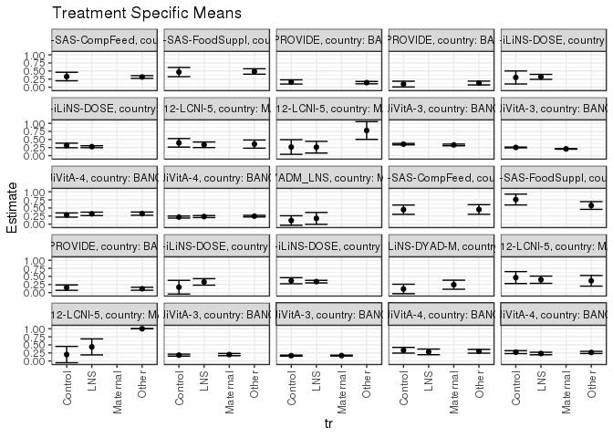

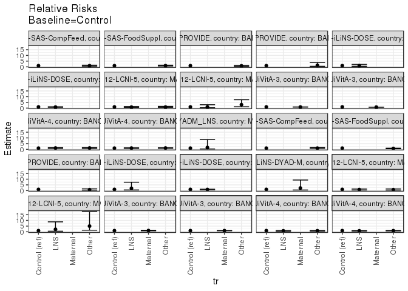

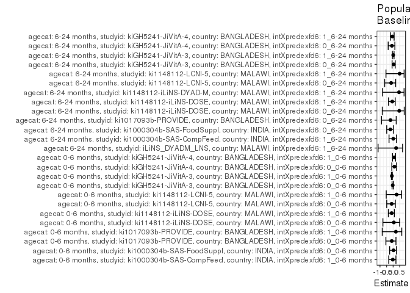

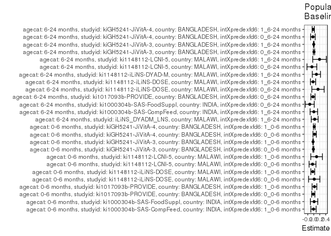

## Results Table

### Parameter: TSM

| agecat | studyid | country | intXpredexfd6 | intervention_level | baseline_level | estimate | ci_lower | ci_upper |
| --- | --- | --- | --- | --- | --- | --- | --- | --- |
| 0-6 months | ki1000304b-SAS-CompFeed | INDIA | 1_0-6 months | Control | NA | 0.3289474 | 0.1971432 | 0.4607516 |
| 0-6 months | ki1000304b-SAS-CompFeed | INDIA | 1_0-6 months | Other | NA | 0.3153846 | 0.2742375 | 0.3565318 |
| 0-6 months | ki1000304b-SAS-FoodSuppl | INDIA | 0_0-6 months | Control | NA | 0.4680851 | 0.3250402 | 0.6111300 |
| 0-6 months | ki1000304b-SAS-FoodSuppl | INDIA | 0_0-6 months | Other | NA | 0.4852941 | 0.4010673 | 0.5695210 |
| 0-6 months | ki1017093b-PROVIDE | BANGLADESH | 0_0-6 months | Control | NA | 0.1612903 | 0.0964856 | 0.2260951 |
| 0-6 months | ki1017093b-PROVIDE | BANGLADESH | 0_0-6 months | Other | NA | 0.1404011 | 0.1039150 | 0.1768873 |
| 0-6 months | ki1017093b-PROVIDE | BANGLADESH | 1_0-6 months | Control | NA | 0.0952381 | 0.0061950 | 0.1842812 |
| 0-6 months | ki1017093b-PROVIDE | BANGLADESH | 1_0-6 months | Other | NA | 0.1280000 | 0.0692564 | 0.1867436 |
| 0-6 months | ki1148112-iLiNS-DOSE | MALAWI | 0_0-6 months | Control | NA | 0.3000000 | 0.0985368 | 0.5014632 |
| 0-6 months | ki1148112-iLiNS-DOSE | MALAWI | 0_0-6 months | LNS | NA | 0.3191489 | 0.2419673 | 0.3963306 |
| 0-6 months | ki1148112-iLiNS-DOSE | MALAWI | 1_0-6 months | Control | NA | 0.3151515 | 0.2442301 | 0.3860729 |
| 0-6 months | ki1148112-iLiNS-DOSE | MALAWI | 1_0-6 months | LNS | NA | 0.2767962 | 0.2466857 | 0.3069068 |
| 0-6 months | ki1148112-LCNI-5 | MALAWI | 0_0-6 months | Control | NA | 0.3962264 | 0.2642531 | 0.5281997 |
| 0-6 months | ki1148112-LCNI-5 | MALAWI | 0_0-6 months | LNS | NA | 0.3362069 | 0.2500468 | 0.4223670 |
| 0-6 months | ki1148112-LCNI-5 | MALAWI | 0_0-6 months | Other | NA | 0.3571429 | 0.2313663 | 0.4829194 |
| 0-6 months | ki1148112-LCNI-5 | MALAWI | 1_0-6 months | Control | NA | 0.2666667 | 0.0404589 | 0.4928745 |
| 0-6 months | ki1148112-LCNI-5 | MALAWI | 1_0-6 months | LNS | NA | 0.2608696 | 0.0794741 | 0.4422650 |
| 0-6 months | ki1148112-LCNI-5 | MALAWI | 1_0-6 months | Other | NA | 0.7777778 | 0.5032297 | 1.0523258 |
| 0-6 months | kiGH5241-JiVitA-3 | BANGLADESH | 0_0-6 months | Control | NA | 0.3555356 | 0.3326990 | 0.3783721 |
| 0-6 months | kiGH5241-JiVitA-3 | BANGLADESH | 0_0-6 months | Maternal | NA | 0.3313812 | 0.3059345 | 0.3568278 |
| 0-6 months | kiGH5241-JiVitA-3 | BANGLADESH | 1_0-6 months | Control | NA | 0.2532538 | 0.2410536 | 0.2654540 |
| 0-6 months | kiGH5241-JiVitA-3 | BANGLADESH | 1_0-6 months | Maternal | NA | 0.2093174 | 0.1991519 | 0.2194830 |
| 0-6 months | kiGH5241-JiVitA-4 | BANGLADESH | 0_0-6 months | Control | NA | 0.2803347 | 0.2157017 | 0.3449677 |
| 0-6 months | kiGH5241-JiVitA-4 | BANGLADESH | 0_0-6 months | LNS | NA | 0.3165468 | 0.2639459 | 0.3691476 |
| 0-6 months | kiGH5241-JiVitA-4 | BANGLADESH | 0_0-6 months | Other | NA | 0.3229167 | 0.2734921 | 0.3723412 |
| 0-6 months | kiGH5241-JiVitA-4 | BANGLADESH | 1_0-6 months | Control | NA | 0.2181818 | 0.1867738 | 0.2495899 |
| 0-6 months | kiGH5241-JiVitA-4 | BANGLADESH | 1_0-6 months | LNS | NA | 0.2334711 | 0.2024696 | 0.2644725 |
| 0-6 months | kiGH5241-JiVitA-4 | BANGLADESH | 1_0-6 months | Other | NA | 0.2457627 | 0.2209033 | 0.2706221 |
| 6-24 months | iLiNS_DYADM_LNS | MALAWI | 1_6-24 months | Control | NA | 0.1111111 | -0.0361910 | 0.2584132 |
| 6-24 months | iLiNS_DYADM_LNS | MALAWI | 1_6-24 months | LNS | NA | 0.1764706 | -0.0073922 | 0.3603334 |
| 6-24 months | ki1000304b-SAS-CompFeed | INDIA | 1_6-24 months | Control | NA | 0.4459459 | 0.3024571 | 0.5894348 |
| 6-24 months | ki1000304b-SAS-CompFeed | INDIA | 1_6-24 months | Other | NA | 0.4521739 | 0.3031506 | 0.6011972 |
| 6-24 months | ki1000304b-SAS-FoodSuppl | INDIA | 0_6-24 months | Control | NA | 0.7600000 | 0.5916590 | 0.9283410 |
| 6-24 months | ki1000304b-SAS-FoodSuppl | INDIA | 0_6-24 months | Other | NA | 0.5757576 | 0.4558622 | 0.6956530 |
| 6-24 months | ki1017093b-PROVIDE | BANGLADESH | 0_6-24 months | Control | NA | 0.1527778 | 0.0695157 | 0.2360399 |
| 6-24 months | ki1017093b-PROVIDE | BANGLADESH | 0_6-24 months | Other | NA | 0.1170213 | 0.0709836 | 0.1630590 |
| 6-24 months | ki1148112-iLiNS-DOSE | MALAWI | 0_6-24 months | Control | NA | 0.1666667 | -0.0452873 | 0.3786206 |
| 6-24 months | ki1148112-iLiNS-DOSE | MALAWI | 0_6-24 months | LNS | NA | 0.3294118 | 0.2289765 | 0.4298471 |
| 6-24 months | ki1148112-iLiNS-DOSE | MALAWI | 1_6-24 months | Control | NA | 0.3663366 | 0.2722993 | 0.4603739 |
| 6-24 months | ki1148112-iLiNS-DOSE | MALAWI | 1_6-24 months | LNS | NA | 0.3383459 | 0.2981083 | 0.3785834 |
| 6-24 months | ki1148112-iLiNS-DYAD-M | MALAWI | 1_6-24 months | Control | NA | 0.1111111 | -0.0354095 | 0.2576317 |
| 6-24 months | ki1148112-iLiNS-DYAD-M | MALAWI | 1_6-24 months | Maternal | NA | 0.2432432 | 0.1037252 | 0.3827612 |
| 6-24 months | ki1148112-LCNI-5 | MALAWI | 0_6-24 months | Control | NA | 0.4642857 | 0.2788664 | 0.6497050 |
| 6-24 months | ki1148112-LCNI-5 | MALAWI | 0_6-24 months | LNS | NA | 0.3972603 | 0.2845883 | 0.5099322 |
| 6-24 months | ki1148112-LCNI-5 | MALAWI | 0_6-24 months | Other | NA | 0.3636364 | 0.1988945 | 0.5283782 |
| 6-24 months | ki1148112-LCNI-5 | MALAWI | 1_6-24 months | Control | NA | 0.2000000 | -0.0524673 | 0.4524673 |
| 6-24 months | ki1148112-LCNI-5 | MALAWI | 1_6-24 months | LNS | NA | 0.4375000 | 0.1899656 | 0.6850344 |
| 6-24 months | ki1148112-LCNI-5 | MALAWI | 1_6-24 months | Other | NA | 1.0000000 | 0.9999999 | 1.0000000 |
| 6-24 months | kiGH5241-JiVitA-3 | BANGLADESH | 0_6-24 months | Control | NA | 0.1827040 | 0.1521531 | 0.2132549 |
| 6-24 months | kiGH5241-JiVitA-3 | BANGLADESH | 0_6-24 months | Maternal | NA | 0.1997455 | 0.1650671 | 0.2344240 |
| 6-24 months | kiGH5241-JiVitA-3 | BANGLADESH | 1_6-24 months | Control | NA | 0.1667149 | 0.1513181 | 0.1821117 |
| 6-24 months | kiGH5241-JiVitA-3 | BANGLADESH | 1_6-24 months | Maternal | NA | 0.1683089 | 0.1544094 | 0.1822085 |
| 6-24 months | kiGH5241-JiVitA-4 | BANGLADESH | 0_6-24 months | Control | NA | 0.3333333 | 0.2447092 | 0.4219574 |
| 6-24 months | kiGH5241-JiVitA-4 | BANGLADESH | 0_6-24 months | LNS | NA | 0.2828947 | 0.1953113 | 0.3704781 |
| 6-24 months | kiGH5241-JiVitA-4 | BANGLADESH | 0_6-24 months | Other | NA | 0.3018182 | 0.2427316 | 0.3609048 |
| 6-24 months | kiGH5241-JiVitA-4 | BANGLADESH | 1_6-24 months | Control | NA | 0.2751236 | 0.2303590 | 0.3198881 |
| 6-24 months | kiGH5241-JiVitA-4 | BANGLADESH | 1_6-24 months | LNS | NA | 0.2324059 | 0.1932695 | 0.2715423 |
| 6-24 months | kiGH5241-JiVitA-4 | BANGLADESH | 1_6-24 months | Other | NA | 0.2656400 | 0.2317631 | 0.2995170 |

### Parameter: E(Y)

| agecat | studyid | country | intXpredexfd6 | intervention_level | baseline_level | estimate | ci_lower | ci_upper |
| --- | --- | --- | --- | --- | --- | --- | --- | --- |
| 0-6 months | ki1000304b-SAS-CompFeed | INDIA | 1_0-6 months | NA | NA | 0.3203883 | 0.2652569 | 0.3755198 |
| 0-6 months | ki1000304b-SAS-FoodSuppl | INDIA | 0_0-6 months | NA | NA | 0.4808743 | 0.4082864 | 0.5534623 |
| 0-6 months | ki1017093b-PROVIDE | BANGLADESH | 0_0-6 months | NA | NA | 0.1458774 | 0.1140331 | 0.1777216 |
| 0-6 months | ki1017093b-PROVIDE | BANGLADESH | 1_0-6 months | NA | NA | 0.1197605 | 0.0703691 | 0.1691519 |
| 0-6 months | ki1148112-iLiNS-DOSE | MALAWI | 0_0-6 months | NA | NA | 0.3167702 | 0.2446854 | 0.3888550 |
| 0-6 months | ki1148112-iLiNS-DOSE | MALAWI | 1_0-6 months | NA | NA | 0.2830375 | 0.2552970 | 0.3107779 |
| 0-6 months | ki1148112-LCNI-5 | MALAWI | 0_0-6 months | NA | NA | 0.3555556 | 0.2928696 | 0.4182416 |
| 0-6 months | ki1148112-LCNI-5 | MALAWI | 1_0-6 months | NA | NA | 0.3617021 | 0.2228488 | 0.5005555 |
| 0-6 months | kiGH5241-JiVitA-3 | BANGLADESH | 0_0-6 months | NA | NA | 0.3439476 | 0.3268991 | 0.3609960 |
| 0-6 months | kiGH5241-JiVitA-3 | BANGLADESH | 1_0-6 months | NA | NA | 0.2308049 | 0.2227254 | 0.2388845 |
| 0-6 months | kiGH5241-JiVitA-4 | BANGLADESH | 0_0-6 months | NA | NA | 0.3109328 | 0.2789227 | 0.3429429 |
| 0-6 months | kiGH5241-JiVitA-4 | BANGLADESH | 1_0-6 months | NA | NA | 0.2351617 | 0.2185966 | 0.2517269 |
| 6-24 months | iLiNS_DYADM_LNS | MALAWI | 1_6-24 months | NA | NA | 0.1428571 | 0.0252358 | 0.2604785 |
| 6-24 months | ki1000304b-SAS-CompFeed | INDIA | 1_6-24 months | NA | NA | 0.4497354 | 0.3430399 | 0.5564310 |
| 6-24 months | ki1000304b-SAS-FoodSuppl | INDIA | 0_6-24 months | NA | NA | 0.6263736 | 0.5264283 | 0.7263189 |
| 6-24 months | ki1017093b-PROVIDE | BANGLADESH | 0_6-24 months | NA | NA | 0.1269231 | 0.0863820 | 0.1674641 |
| 6-24 months | ki1148112-iLiNS-DOSE | MALAWI | 0_6-24 months | NA | NA | 0.3092784 | 0.2168216 | 0.4017351 |
| 6-24 months | ki1148112-iLiNS-DOSE | MALAWI | 1_6-24 months | NA | NA | 0.3428120 | 0.3058068 | 0.3798172 |
| 6-24 months | ki1148112-iLiNS-DYAD-M | MALAWI | 1_6-24 months | NA | NA | 0.2000000 | 0.0933131 | 0.3066869 |
| 6-24 months | ki1148112-LCNI-5 | MALAWI | 0_6-24 months | NA | NA | 0.4029851 | 0.3196248 | 0.4863454 |
| 6-24 months | ki1148112-LCNI-5 | MALAWI | 1_6-24 months | NA | NA | 0.3928571 | 0.2086404 | 0.5770738 |
| 6-24 months | kiGH5241-JiVitA-3 | BANGLADESH | 0_6-24 months | NA | NA | 0.1910392 | 0.1679832 | 0.2140952 |
| 6-24 months | kiGH5241-JiVitA-3 | BANGLADESH | 1_6-24 months | NA | NA | 0.1675451 | 0.1572073 | 0.1778828 |
| 6-24 months | kiGH5241-JiVitA-4 | BANGLADESH | 0_6-24 months | NA | NA | 0.3044248 | 0.2613466 | 0.3475030 |
| 6-24 months | kiGH5241-JiVitA-4 | BANGLADESH | 1_6-24 months | NA | NA | 0.2591936 | 0.2368055 | 0.2815818 |

### Parameter: RR

| agecat | studyid | country | intXpredexfd6 | intervention_level | baseline_level | estimate | ci_lower | ci_upper |
| --- | --- | --- | --- | --- | --- | --- | --- | --- |
| 0-6 months | ki1000304b-SAS-CompFeed | INDIA | 1_0-6 months | Control | Control | 1.0000000 | 1.0000000 | 1.0000000 |
| 0-6 months | ki1000304b-SAS-CompFeed | INDIA | 1_0-6 months | Other | Control | 0.9587692 | 0.6290672 | 1.4612723 |
| 0-6 months | ki1000304b-SAS-FoodSuppl | INDIA | 0_0-6 months | Control | Control | 1.0000000 | 1.0000000 | 1.0000000 |
| 0-6 months | ki1000304b-SAS-FoodSuppl | INDIA | 0_0-6 months | Other | Control | 1.0367647 | 0.7295430 | 1.4733621 |
| 0-6 months | ki1017093b-PROVIDE | BANGLADESH | 0_0-6 months | Control | Control | 1.0000000 | 1.0000000 | 1.0000000 |
| 0-6 months | ki1017093b-PROVIDE | BANGLADESH | 0_0-6 months | Other | Control | 0.8704871 | 0.5394485 | 1.4046712 |
| 0-6 months | ki1017093b-PROVIDE | BANGLADESH | 1_0-6 months | Control | Control | 1.0000000 | 1.0000000 | 1.0000000 |
| 0-6 months | ki1017093b-PROVIDE | BANGLADESH | 1_0-6 months | Other | Control | 1.3439999 | 0.4743233 | 3.8082379 |
| 0-6 months | ki1148112-iLiNS-DOSE | MALAWI | 0_0-6 months | Control | Control | 1.0000000 | 1.0000000 | 1.0000000 |
| 0-6 months | ki1148112-iLiNS-DOSE | MALAWI | 0_0-6 months | LNS | Control | 1.0638298 | 0.5210619 | 2.1719756 |
| 0-6 months | ki1148112-iLiNS-DOSE | MALAWI | 1_0-6 months | Control | Control | 1.0000000 | 1.0000000 | 1.0000000 |
| 0-6 months | ki1148112-iLiNS-DOSE | MALAWI | 1_0-6 months | LNS | Control | 0.8782957 | 0.6840500 | 1.1277004 |
| 0-6 months | ki1148112-LCNI-5 | MALAWI | 0_0-6 months | Control | Control | 1.0000000 | 1.0000000 | 1.0000000 |
| 0-6 months | ki1148112-LCNI-5 | MALAWI | 0_0-6 months | LNS | Control | 0.8485222 | 0.5573767 | 1.2917473 |
| 0-6 months | ki1148112-LCNI-5 | MALAWI | 0_0-6 months | Other | Control | 0.9013605 | 0.5551134 | 1.4635763 |
| 0-6 months | ki1148112-LCNI-5 | MALAWI | 1_0-6 months | Control | Control | 1.0000000 | 1.0000000 | 1.0000000 |
| 0-6 months | ki1148112-LCNI-5 | MALAWI | 1_0-6 months | LNS | Control | 0.9782609 | 0.3266609 | 2.9296264 |
| 0-6 months | ki1148112-LCNI-5 | MALAWI | 1_0-6 months | Other | Control | 2.9166667 | 1.1637515 | 7.3099321 |
| 0-6 months | kiGH5241-JiVitA-3 | BANGLADESH | 0_0-6 months | Control | Control | 1.0000000 | 1.0000000 | 1.0000000 |
| 0-6 months | kiGH5241-JiVitA-3 | BANGLADESH | 0_0-6 months | Maternal | Control | 0.9320620 | 0.8432742 | 1.0301981 |
| 0-6 months | kiGH5241-JiVitA-3 | BANGLADESH | 1_0-6 months | Control | Control | 1.0000000 | 1.0000000 | 1.0000000 |
| 0-6 months | kiGH5241-JiVitA-3 | BANGLADESH | 1_0-6 months | Maternal | Control | 0.8265124 | 0.7718261 | 0.8850735 |
| 0-6 months | kiGH5241-JiVitA-4 | BANGLADESH | 0_0-6 months | Control | Control | 1.0000000 | 1.0000000 | 1.0000000 |
| 0-6 months | kiGH5241-JiVitA-4 | BANGLADESH | 0_0-6 months | LNS | Control | 1.1291743 | 0.8496960 | 1.5005772 |
| 0-6 months | kiGH5241-JiVitA-4 | BANGLADESH | 0_0-6 months | Other | Control | 1.1518968 | 0.8734492 | 1.5191109 |
| 0-6 months | kiGH5241-JiVitA-4 | BANGLADESH | 1_0-6 months | Control | Control | 1.0000000 | 1.0000000 | 1.0000000 |
| 0-6 months | kiGH5241-JiVitA-4 | BANGLADESH | 1_0-6 months | LNS | Control | 1.0700758 | 0.8797271 | 1.3016105 |
| 0-6 months | kiGH5241-JiVitA-4 | BANGLADESH | 1_0-6 months | Other | Control | 1.1264124 | 0.9446821 | 1.3431025 |
| 6-24 months | iLiNS_DYADM_LNS | MALAWI | 1_6-24 months | Control | Control | 1.0000000 | 1.0000000 | 1.0000000 |
| 6-24 months | iLiNS_DYADM_LNS | MALAWI | 1_6-24 months | LNS | Control | 1.5882353 | 0.2941942 | 8.5742383 |
| 6-24 months | ki1000304b-SAS-CompFeed | INDIA | 1_6-24 months | Control | Control | 1.0000000 | 1.0000000 | 1.0000000 |
| 6-24 months | ki1000304b-SAS-CompFeed | INDIA | 1_6-24 months | Other | Control | 1.0139657 | 0.6405101 | 1.6051682 |
| 6-24 months | ki1000304b-SAS-FoodSuppl | INDIA | 0_6-24 months | Control | Control | 1.0000000 | 1.0000000 | 1.0000000 |
| 6-24 months | ki1000304b-SAS-FoodSuppl | INDIA | 0_6-24 months | Other | Control | 0.7575758 | 0.5589759 | 1.0267367 |
| 6-24 months | ki1017093b-PROVIDE | BANGLADESH | 0_6-24 months | Control | Control | 1.0000000 | 1.0000000 | 1.0000000 |
| 6-24 months | ki1017093b-PROVIDE | BANGLADESH | 0_6-24 months | Other | Control | 0.7659574 | 0.3911051 | 1.5000848 |
| 6-24 months | ki1148112-iLiNS-DOSE | MALAWI | 0_6-24 months | Control | Control | 1.0000000 | 1.0000000 | 1.0000000 |
| 6-24 months | ki1148112-iLiNS-DOSE | MALAWI | 0_6-24 months | LNS | Control | 1.9764706 | 0.5344864 | 7.3087654 |
| 6-24 months | ki1148112-iLiNS-DOSE | MALAWI | 1_6-24 months | Control | Control | 1.0000000 | 1.0000000 | 1.0000000 |
| 6-24 months | ki1148112-iLiNS-DOSE | MALAWI | 1_6-24 months | LNS | Control | 0.9235928 | 0.6960105 | 1.2255901 |
| 6-24 months | ki1148112-iLiNS-DYAD-M | MALAWI | 1_6-24 months | Control | Control | 1.0000000 | 1.0000000 | 1.0000000 |
| 6-24 months | ki1148112-iLiNS-DYAD-M | MALAWI | 1_6-24 months | Maternal | Control | 2.1891892 | 0.5197045 | 9.2216811 |
| 6-24 months | ki1148112-LCNI-5 | MALAWI | 0_6-24 months | Control | Control | 1.0000000 | 1.0000000 | 1.0000000 |
| 6-24 months | ki1148112-LCNI-5 | MALAWI | 0_6-24 months | LNS | Control | 0.8556375 | 0.5242750 | 1.3964341 |
| 6-24 months | ki1148112-LCNI-5 | MALAWI | 0_6-24 months | Other | Control | 0.7832168 | 0.4281504 | 1.4327408 |
| 6-24 months | ki1148112-LCNI-5 | MALAWI | 1_6-24 months | Control | Control | 1.0000000 | 1.0000000 | 1.0000000 |
| 6-24 months | ki1148112-LCNI-5 | MALAWI | 1_6-24 months | LNS | Control | 2.1875000 | 0.5484958 | 8.7241435 |
| 6-24 months | ki1148112-LCNI-5 | MALAWI | 1_6-24 months | Other | Control | 4.9999999 | 1.4149598 | 17.6683450 |
| 6-24 months | kiGH5241-JiVitA-3 | BANGLADESH | 0_6-24 months | Control | Control | 1.0000000 | 1.0000000 | 1.0000000 |
| 6-24 months | kiGH5241-JiVitA-3 | BANGLADESH | 0_6-24 months | Maternal | Control | 1.0932740 | 0.8590957 | 1.3912861 |
| 6-24 months | kiGH5241-JiVitA-3 | BANGLADESH | 1_6-24 months | Control | Control | 1.0000000 | 1.0000000 | 1.0000000 |
| 6-24 months | kiGH5241-JiVitA-3 | BANGLADESH | 1_6-24 months | Maternal | Control | 1.0095613 | 0.8919628 | 1.1426643 |
| 6-24 months | kiGH5241-JiVitA-4 | BANGLADESH | 0_6-24 months | Control | Control | 1.0000000 | 1.0000000 | 1.0000000 |
| 6-24 months | kiGH5241-JiVitA-4 | BANGLADESH | 0_6-24 months | LNS | Control | 0.8486842 | 0.5642504 | 1.2764987 |
| 6-24 months | kiGH5241-JiVitA-4 | BANGLADESH | 0_6-24 months | Other | Control | 0.9054545 | 0.6508628 | 1.2596324 |
| 6-24 months | kiGH5241-JiVitA-4 | BANGLADESH | 1_6-24 months | Control | Control | 1.0000000 | 1.0000000 | 1.0000000 |
| 6-24 months | kiGH5241-JiVitA-4 | BANGLADESH | 1_6-24 months | LNS | Control | 0.8447328 | 0.6683987 | 1.0675867 |
| 6-24 months | kiGH5241-JiVitA-4 | BANGLADESH | 1_6-24 months | Other | Control | 0.9655300 | 0.7852138 | 1.1872539 |

### Parameter: PAR

| agecat | studyid | country | intXpredexfd6 | intervention_level | baseline_level | estimate | ci_lower | ci_upper |
| --- | --- | --- | --- | --- | --- | --- | --- | --- |
| 0-6 months | ki1000304b-SAS-CompFeed | INDIA | 1_0-6 months | Control | NA | -0.0085590 | -0.0960947 | 0.0789767 |
| 0-6 months | ki1000304b-SAS-FoodSuppl | INDIA | 0_0-6 months | Control | NA | 0.0127892 | -0.1105818 | 0.1361602 |
| 0-6 months | ki1017093b-PROVIDE | BANGLADESH | 0_0-6 months | Control | NA | -0.0154129 | -0.0702926 | 0.0394667 |
| 0-6 months | ki1017093b-PROVIDE | BANGLADESH | 1_0-6 months | Control | NA | 0.0245224 | -0.0553532 | 0.1043979 |
| 0-6 months | ki1148112-iLiNS-DOSE | MALAWI | 0_0-6 months | Control | NA | 0.0167702 | -0.1721737 | 0.2057141 |
| 0-6 months | ki1148112-iLiNS-DOSE | MALAWI | 1_0-6 months | Control | NA | -0.0321140 | -0.0966311 | 0.0324030 |
| 0-6 months | ki1148112-LCNI-5 | MALAWI | 0_0-6 months | Control | NA | -0.0406709 | -0.1553058 | 0.0739641 |
| 0-6 months | ki1148112-LCNI-5 | MALAWI | 1_0-6 months | Control | NA | 0.0950355 | -0.0993573 | 0.2894282 |
| 0-6 months | kiGH5241-JiVitA-3 | BANGLADESH | 0_0-6 months | Control | NA | -0.0115880 | -0.0280257 | 0.0048497 |
| 0-6 months | kiGH5241-JiVitA-3 | BANGLADESH | 1_0-6 months | Control | NA | -0.0224489 | -0.0308530 | -0.0140448 |
| 0-6 months | kiGH5241-JiVitA-4 | BANGLADESH | 0_0-6 months | Control | NA | 0.0305981 | -0.0259391 | 0.0871352 |
| 0-6 months | kiGH5241-JiVitA-4 | BANGLADESH | 1_0-6 months | Control | NA | 0.0169799 | -0.0102150 | 0.0441748 |
| 6-24 months | iLiNS_DYADM_LNS | MALAWI | 1_6-24 months | Control | NA | 0.0317460 | -0.0832098 | 0.1467019 |
| 6-24 months | ki1000304b-SAS-CompFeed | INDIA | 1_6-24 months | Control | NA | 0.0037895 | -0.1219572 | 0.1295362 |
| 6-24 months | ki1000304b-SAS-FoodSuppl | INDIA | 0_6-24 months | Control | NA | -0.1336264 | -0.2844808 | 0.0172280 |
| 6-24 months | ki1017093b-PROVIDE | BANGLADESH | 0_6-24 months | Control | NA | -0.0258547 | -0.0946775 | 0.0429681 |
| 6-24 months | ki1148112-iLiNS-DOSE | MALAWI | 0_6-24 months | Control | NA | 0.1426117 | -0.0631974 | 0.3484208 |
| 6-24 months | ki1148112-iLiNS-DOSE | MALAWI | 1_6-24 months | Control | NA | -0.0235246 | -0.1094924 | 0.0624431 |
| 6-24 months | ki1148112-iLiNS-DYAD-M | MALAWI | 1_6-24 months | Control | NA | 0.0888889 | -0.0482184 | 0.2259962 |
| 6-24 months | ki1148112-LCNI-5 | MALAWI | 0_6-24 months | Control | NA | -0.0613006 | -0.2254998 | 0.1028985 |
| 6-24 months | ki1148112-LCNI-5 | MALAWI | 1_6-24 months | Control | NA | 0.1928571 | -0.0355004 | 0.4212146 |
| 6-24 months | kiGH5241-JiVitA-3 | BANGLADESH | 0_6-24 months | Control | NA | 0.0083352 | -0.0142910 | 0.0309614 |
| 6-24 months | kiGH5241-JiVitA-3 | BANGLADESH | 1_6-24 months | Control | NA | 0.0008302 | -0.0099695 | 0.0116298 |
| 6-24 months | kiGH5241-JiVitA-4 | BANGLADESH | 0_6-24 months | Control | NA | -0.0289086 | -0.1054657 | 0.0476486 |
| 6-24 months | kiGH5241-JiVitA-4 | BANGLADESH | 1_6-24 months | Control | NA | -0.0159299 | -0.0537251 | 0.0218653 |

### Parameter: PAF

| agecat | studyid | country | intXpredexfd6 | intervention_level | baseline_level | estimate | ci_lower | ci_upper |
| --- | --- | --- | --- | --- | --- | --- | --- | --- |
| 0-6 months | ki1000304b-SAS-CompFeed | INDIA | 1_0-6 months | Control | NA | -0.0267145 | -0.3356234 | 0.2107486 |
| 0-6 months | ki1000304b-SAS-FoodSuppl | INDIA | 0_0-6 months | Control | NA | 0.0265957 | -0.2669791 | 0.2521456 |
| 0-6 months | ki1017093b-PROVIDE | BANGLADESH | 0_0-6 months | Control | NA | -0.1056568 | -0.5531659 | 0.2129128 |
| 0-6 months | ki1017093b-PROVIDE | BANGLADESH | 1_0-6 months | Control | NA | 0.2047619 | -0.8299617 | 0.6544170 |
| 0-6 months | ki1148112-iLiNS-DOSE | MALAWI | 0_0-6 months | Control | NA | 0.0529412 | -0.7778474 | 0.4955020 |
| 0-6 months | ki1148112-iLiNS-DOSE | MALAWI | 1_0-6 months | Control | NA | -0.1134621 | -0.3663764 | 0.0926380 |
| 0-6 months | ki1148112-LCNI-5 | MALAWI | 0_0-6 months | Control | NA | -0.1143868 | -0.4884734 | 0.1656835 |
| 0-6 months | ki1148112-LCNI-5 | MALAWI | 1_0-6 months | Control | NA | 0.2627451 | -0.5250649 | 0.6435924 |
| 0-6 months | kiGH5241-JiVitA-3 | BANGLADESH | 0_0-6 months | Control | NA | -0.0336912 | -0.0827577 | 0.0131518 |
| 0-6 months | kiGH5241-JiVitA-3 | BANGLADESH | 1_0-6 months | Control | NA | -0.0972634 | -0.1341152 | -0.0616090 |
| 0-6 months | kiGH5241-JiVitA-4 | BANGLADESH | 0_0-6 months | Control | NA | 0.0984073 | -0.1032521 | 0.2632062 |
| 0-6 months | kiGH5241-JiVitA-4 | BANGLADESH | 1_0-6 months | Control | NA | 0.0722053 | -0.0509050 | 0.1808936 |
| 6-24 months | iLiNS_DYADM_LNS | MALAWI | 1_6-24 months | Control | NA | 0.2222222 | -1.1453105 | 0.7180183 |
| 6-24 months | ki1000304b-SAS-CompFeed | INDIA | 1_6-24 months | Control | NA | 0.0084261 | -0.3139345 | 0.2516987 |
| 6-24 months | ki1000304b-SAS-FoodSuppl | INDIA | 0_6-24 months | Control | NA | -0.2133333 | -0.4886307 | 0.0110524 |
| 6-24 months | ki1017093b-PROVIDE | BANGLADESH | 0_6-24 months | Control | NA | -0.2037037 | -0.8846957 | 0.2312273 |
| 6-24 months | ki1148112-iLiNS-DOSE | MALAWI | 0_6-24 months | Control | NA | 0.4611111 | -0.8272710 | 0.8410738 |
| 6-24 months | ki1148112-iLiNS-DOSE | MALAWI | 1_6-24 months | Control | NA | -0.0686225 | -0.3512782 | 0.1549082 |
| 6-24 months | ki1148112-iLiNS-DYAD-M | MALAWI | 1_6-24 months | Control | NA | 0.4444444 | -0.8070247 | 0.8291988 |
| 6-24 months | ki1148112-LCNI-5 | MALAWI | 0_6-24 months | Control | NA | -0.1521164 | -0.6418859 | 0.1915564 |
| 6-24 months | ki1148112-LCNI-5 | MALAWI | 1_6-24 months | Control | NA | 0.4909091 | -0.5460329 | 0.8323622 |
| 6-24 months | kiGH5241-JiVitA-3 | BANGLADESH | 0_6-24 months | Control | NA | 0.0436308 | -0.0819550 | 0.1546394 |
| 6-24 months | kiGH5241-JiVitA-3 | BANGLADESH | 1_6-24 months | Control | NA | 0.0049549 | -0.0616575 | 0.0673878 |
| 6-24 months | kiGH5241-JiVitA-4 | BANGLADESH | 0_6-24 months | Control | NA | -0.0949612 | -0.3777647 | 0.1297933 |
| 6-24 months | kiGH5241-JiVitA-4 | BANGLADESH | 1_6-24 months | Control | NA | -0.0614596 | -0.2176127 | 0.0746676 |